# Supplemental Rarefied Analyses

### 1.3.3 Compositional RDA plots

#### Explained Variance in RDA’s

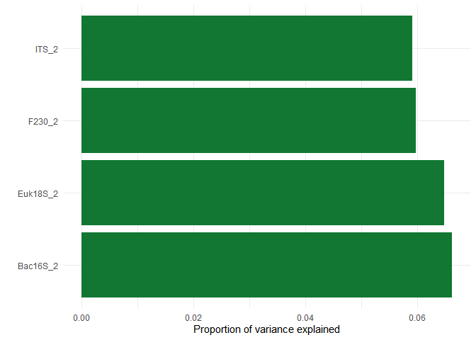

Figure 1.13: Proportion of community structural variance explained by RDA axes constrained by season. Model names are described as the targeted gene (16S, 18S, ITS, or, F230), summarization level (ESV, genus, or functional groupings) and the soil layers represented in the rda model (MIN = 0-10 cm depth mineral soil samples, LFH = L, FH, or LFH samples).

#### Bacterial (16S)

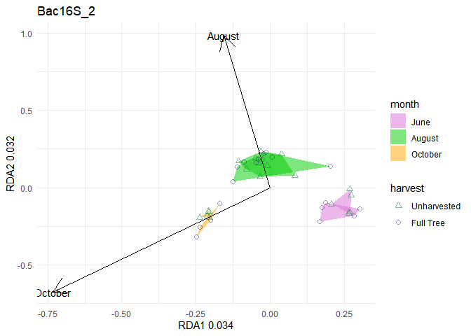

#### Fungal (ITS)

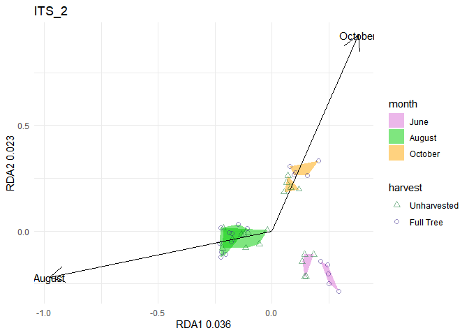

#### Arthropods (F230)

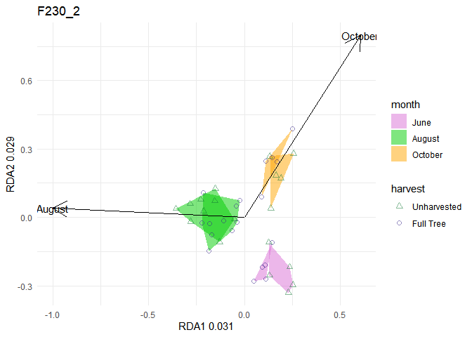

#### Eukaryotes (18S)

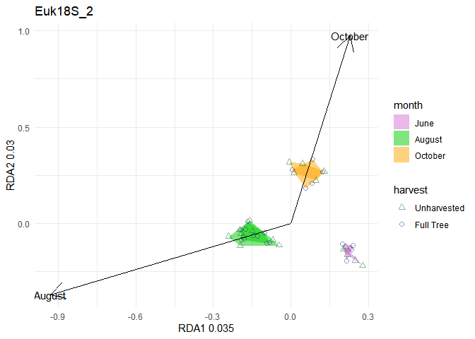

RDAs of rarefied datasets and unrarefied datasets were both low (less than 10% of variance explained by seasonal variation). Seasonal impacts on both Unharvested and Harvested treatments were very similar in rarefied an unrarefied analyses. There were no changes to the conclusions made from the unrarefied analyses.

### 1.3.4 Differences in specific organisms

#### Bac16S

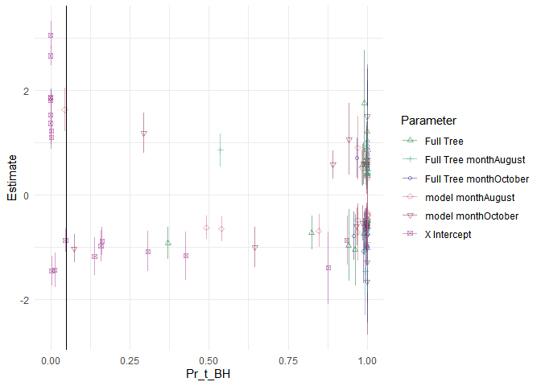

Graph shows 20 most significant organisms for each parameter.

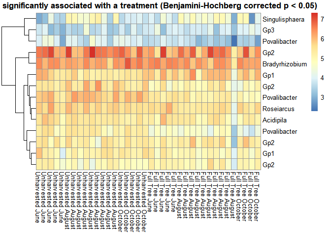

#### ITS

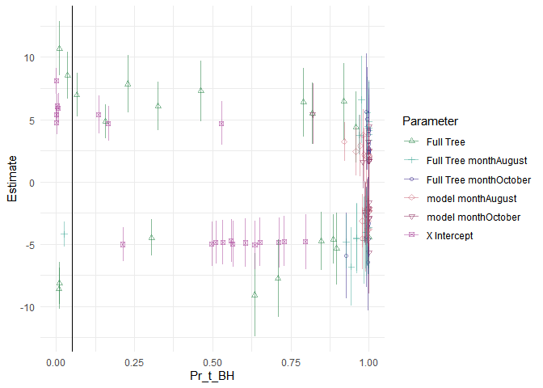

Graph shows 20 most significant organisms for each parameter.

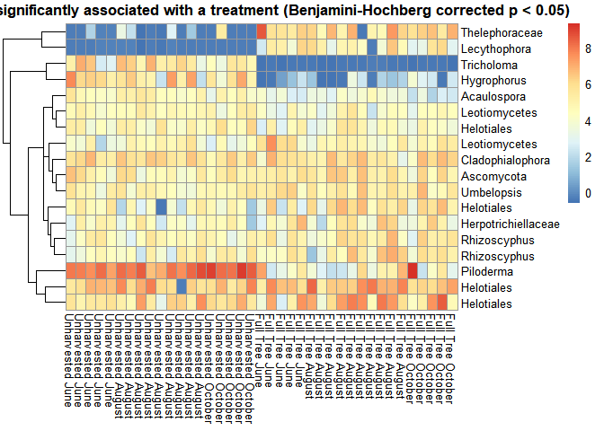

#### F230

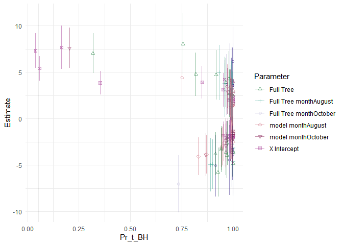

Graph shows 20 most significant organisms for each parameter.

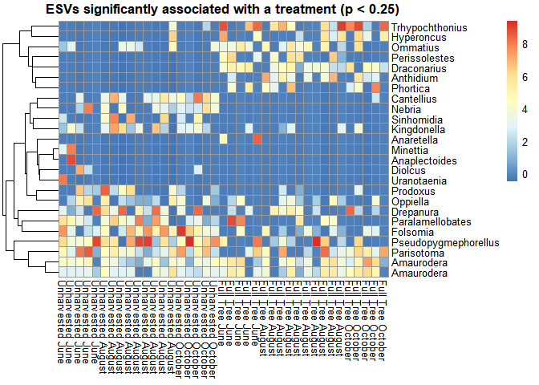

#### Euk18S

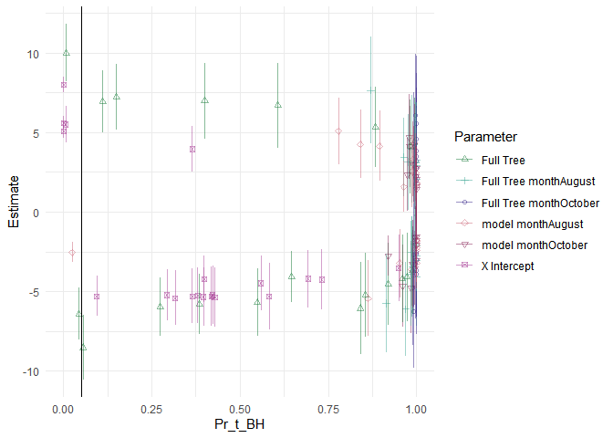

Graph shows 20 most significant organisms for each parameter.

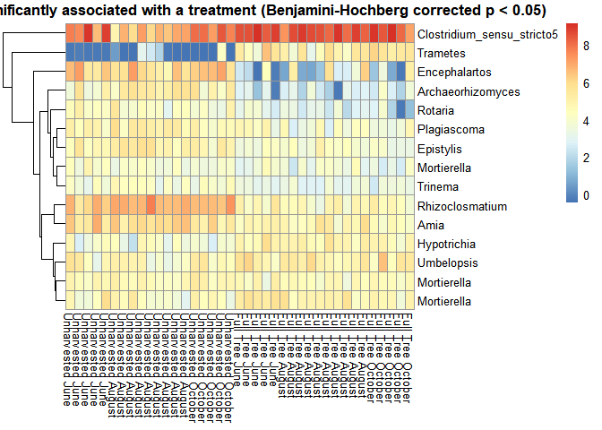

Table 1.3: Taxonomic information for ESVs identified as significantly responding to seasonal effects.

| dataset | Domain | Kingdom | Phylum | Class | Order | Family | Genus | Species |
| --- | --- | --- | --- | --- | --- | --- | --- | --- |
| Bac16S_2 | Bacteria | NA | Acidobacteria | Acidobacteria_Gp1 | Acidipila | Acidipila | Acidipila | NA |
| Bac16S_2 | Bacteria | NA | Proteobacteria | Alphaproteobacteria | Rhizobiales | Bradyrhizobiaceae | Bradyrhizobium | NA |
| Bac16S_2 | Bacteria | NA | Acidobacteria | Acidobacteria_Gp1 | Gp1 | Gp1 | Gp1 | NA |
| Bac16S_2 | Bacteria | NA | Acidobacteria | Acidobacteria_Gp2 | Gp2 | Gp2 | Gp2 | NA |
| Bac16S_2 | Bacteria | NA | Proteobacteria | Alphaproteobacteria | Rhizobiales | Roseiarcaceae | Roseiarcus | NA |
| Bac16S_2 | Bacteria | NA | Proteobacteria | Gammaproteobacteria | Nevskiales | Steroidobacteraceae | Povalibacter | NA |
| Bac16S_2 | Bacteria | NA | Planctomycetes | Planctomycetacia | Planctomycetales | Isosphaeraceae | Singulisphaera | NA |
| Bac16S_2 | Bacteria | NA | Acidobacteria | Acidobacteria_Gp3 | Gp3 | Gp3 | Gp3 | NA |
| ITS_2 | NA | Fungi | Ascomycota | Leotiomycetes | Leotiomycetes_unidentified | Leotiomycetes_unidentified_1 | Leotiomycetes_unidentified_1 | Leotiomycetes_sp\|SH207169.06FU |
| ITS_2 | NA | Fungi | Ascomycota | Sordariomycetes | Coniochaetales | Coniochaetaceae | Lecythophora | Lecythophora_fasciculata\|SH226440.06FU |
| ITS_2 | NA | Fungi | Ascomycota | Ascomycota_unidentified | Ascomycota_unidentified_1 | Ascomycota_unidentified_1 | Ascomycota_unidentified_1_1 | Ascomycota_sp\|SH197703.06FU |
| ITS_2 | NA | Fungi | Zygomycota | Incertae_sedis_10 | Mucorales | Umbelopsidaceae | Umbelopsis | Umbelopsis_dimorpha\|SH219309.06FU |
| ITS_2 | NA | Fungi | Ascomycota | Leotiomycetes | Helotiales | Helotiaceae | Rhizoscyphus | Rhizoscyphus_ericae\|SH207166.06FU |
| ITS_2 | NA | Fungi | Glomeromycota | Glomeromycetes | Diversisporales | Acaulosporaceae | Acaulospora | Acaulospora_nivalis\|SH195298.06FU |
| ITS_2 | NA | Fungi | Ascomycota | Leotiomycetes | Helotiales | Helotiales_unidentified | Helotiales_unidentified_1 | Helotiales_sp\|SH213012.06FU |
| ITS_2 | NA | Fungi | Basidiomycota | Agaricomycetes | Thelephorales | Thelephoraceae | Thelephoraceae_unidentified | Thelephoraceae_sp\|SH195956.06FU |
| ITS_2 | NA | Fungi | Basidiomycota | Agaricomycetes | Atheliales | Atheliaceae | Piloderma | Piloderma_sphaerosporum\|SH222528.06FU |
| ITS_2 | NA | Fungi | Ascomycota | Leotiomycetes | Leotiomycetes_unidentified | Leotiomycetes_unidentified_1 | Leotiomycetes_unidentified_1 | Leotiomycetes_sp\|SH207178.06FU |
| ITS_2 | NA | Fungi | Basidiomycota | Agaricomycetes | Agaricales | Hygrophoraceae | Hygrophorus | Hygrophorus_sp\|SH223864.06FU |
| ITS_2 | NA | Fungi | Ascomycota | Leotiomycetes | Helotiales | Helotiales_unidentified | Helotiales_unidentified_1 | Helotiales_sp\|SH213015.06FU |
| ITS_2 | NA | Fungi | Ascomycota | Eurotiomycetes | Chaetothyriales | Herpotrichiellaceae | Herpotrichiellaceae_unidentified | Herpotrichiellaceae_sp\|SH226546.06FU |
| ITS_2 | NA | Fungi | Ascomycota | Eurotiomycetes | Chaetothyriales | Herpotrichiellaceae | Cladophialophora | Cladophialophora_sp\|SH226821.06FU |
| ITS_2 | NA | Fungi | Ascomycota | Leotiomycetes | Helotiales | Helotiales_unidentified | Helotiales_unidentified_1 | Helotiales_sp\|SH198435.06FU |
| ITS_2 | NA | Fungi | Basidiomycota | Agaricomycetes | Agaricales | Tricholomataceae | Tricholoma | Tricholoma_aestuans\|SH194220.06FU |
| ITS_2 | NA | Fungi | Ascomycota | Leotiomycetes | Helotiales | Helotiales_unidentified | Helotiales_unidentified_1 | Helotiales_sp\|SH209209.06FU |
| F230_2 | NA | Metazoa | Arthropoda | Insecta | Odonata | Perilestidae | Perissolestes | Perissolestes_guianensis |
| F230_2 | NA | Metazoa | Arthropoda | Insecta | Coleoptera | Carabidae | Nebria | Nebria_piperi |
| F230_2 | NA | Metazoa | Arthropoda | Insecta | Diptera | Culicidae | Uranotaenia | Uranotaenia_socialis |
| F230_2 | NA | Metazoa | Arthropoda | Insecta | Diptera | Asilidae | Ommatius | Ommatius_terminalis |
| F230_2 | NA | Metazoa | Arthropoda | Arachnida | Sarcoptiformes | Oppiidae | Oppiella | Oppiella_nova |
| F230_2 | NA | Metazoa | Arthropoda | Insecta | Hymenoptera | Megachilidae | Anthidium | Anthidium_toro |
| F230_2 | NA | Metazoa | Arthropoda | Collembola | Entomobryomorpha | Entomobryidae | Drepanura | Drepanura_mongolica |
| F230_2 | NA | Metazoa | Arthropoda | Insecta | Diptera | Lauxaniidae | Minettia | Minettia_flaveola |
| F230_2 | NA | Metazoa | Arthropoda | Collembola | Entomobryomorpha | Entomobryidae | Sinhomidia | Sinhomidia_bicolor |
| F230_2 | NA | Metazoa | Arthropoda | Insecta | Coleoptera | Staphylinidae | Amaurodera | Amaurodera_yaoana |
| F230_2 | NA | Metazoa | Arthropoda | Collembola | Entomobryomorpha | Isotomidae | Parisotoma | Parisotoma_ekmani |
| F230_2 | NA | Metazoa | Arthropoda | Insecta | Hemiptera | Scutelleridae | Hyperoncus | Hyperoncus_lateritius |
| F230_2 | NA | Metazoa | Arthropoda | Arachnida | Araneae | Amaurobiidae | Draconarius | Draconarius_anthonyi |
| F230_2 | NA | Metazoa | Arthropoda | Insecta | Lepidoptera | Noctuidae | Anaplectoides | Anaplectoides_pressus |
| F230_2 | NA | Metazoa | Arthropoda | Insecta | Hemiptera | Scutelleridae | Diolcus | Diolcus_irroratus |
| F230_2 | NA | Metazoa | Arthropoda | Hexanauplia | Sessilia | Pyrgomatidae | Cantellius | Cantellius_iwayama |
| F230_2 | NA | Metazoa | Arthropoda | Collembola | Entomobryomorpha | Isotomidae | Folsomia | Folsomia_nivalis |
| F230_2 | NA | Metazoa | Arthropoda | Insecta | Lepidoptera | Prodoxidae | Prodoxus | Prodoxus_atascosanellus |
| F230_2 | NA | Metazoa | Arthropoda | Insecta | Orthoptera | Acrididae | Kingdonella | Kingdonella_bicollina |
| F230_2 | NA | Metazoa | Arthropoda | Arachnida | Trombidiformes | Pygmephoridae | Pseudopygmephorellus | Pseudopygmephorellus_mazandaranicus |
| F230_2 | NA | Metazoa | Arthropoda | Arachnida | Sarcoptiformes | Punctoribatidae | Paralamellobates | Paralamellobates_misella |
| F230_2 | NA | Metazoa | Arthropoda | Insecta | Diptera | Drosophilidae | Phortica | Phortica_afoliolata |
| F230_2 | NA | Metazoa | Arthropoda | Arachnida | Sarcoptiformes | Trhypochthoniidae | Trhypochthonius | Trhypochthonius_tectorum |
| F230_2 | NA | Metazoa | Arthropoda | Insecta | Diptera | Cecidomyiidae | Anaretella | Anaretella_iola |
| Euk18S_2 | Eukaryota | Fungi | Ascomycota | Sordariomycetes | Pleurotheciales | Pleurotheciaceae | Plagiascoma | NA |
| Euk18S_2 | Bacteria | Bacteria_undef | Firmicutes | Clostridia | Clostridiales | Clostridiaceae | Clostridium_sensu_stricto_15 | NA |
| Euk18S_2 | Eukaryota | Rhizaria | Cercozoa | Imbricatea | Imbricatea_Imbricatea_undef | Euglyphida | Trinema | NA |
| Euk18S_2 | Eukaryota | Fungi | Mucoromycota | Mucoromycota_Incertae_Sedis | Mortierellales | Mortierellaceae | Mortierella | NA |
| Euk18S_2 | Eukaryota | Fungi | Mucoromycota | Mucoromycota_Incertae_Sedis | Umbelopsidales | Umbelopsidaceae | Umbelopsis | NA |
| Euk18S_2 | Eukaryota | Alveolata | Ciliophora | Intramacronucleata | Spirotrichea | Hypotrichia | Hypotrichia_uncultured | NA |
| Euk18S_2 | Eukaryota | Alveolata | Ciliophora | Intramacronucleata | Conthreep | Oligohymenophorea | Epistylis | NA |
| Euk18S_2 | Eukaryota | Fungi | Ascomycota | Dothideomycetes | Pleosporales | Pleosporales_Pleosporales_undef | Amia | NA |
| Euk18S_2 | Eukaryota | Fungi | Chytridiomycota | Chytridiomycetes | Chytridiales | Chytriomycetaceae | Rhizoclosmatium | NA |
| Euk18S_2 | Eukaryota | Animalia | Rotifera | Bdelloidea | Bdelloidea_Bdelloidea_undef | Bdelloidea_Bdelloidea_undef_Bdelloidea_undef_undef | Rotaria | NA |
| Euk18S_2 | Eukaryota | Fungi | Basidiomycota | Agaricomycetes | Polyporales | Polyporales_Incertae_Sedis | Trametes | NA |
| Euk18S_2 | Eukaryota | Fungi | Ascomycota | Archaeorhizomycetes | Archaeorhizomycetales | Archaeorhizomycetaceae | Archaeorhizomyces | NA |
| Euk18S_2 | Eukaryota | Chloroplastida | Phragmoplastophyta | Embryophyta | Cycadales | Cycadales_Cycadales_undef | Encephalartos | NA |

Bacterial ESV with significant changes in rarefied datasets did not have strong, clear trends of seasonal change, with seasonal patterns being much less clear than those observed for bacterial ESV in unrarefied datasets. Across the remaining datasets, detected effects were mostly related to harvest treatment differences, not seasonal differences, in both rarefied and unrarefied analyses. All of the phylogenetic groups identified in rarefied 16S ITS, and F230 datasets were also found in unrarefied analyses. There was only one group that was detected in rarefied analyses of 18S communities that was not detected in the unrarefied analyses.